# Prática 5: Teste de Hipótese

Guilherme Rodrigues

21 de fevereiro de 2026

```r
options(encoding = "UTF-8")
#limpar a memória
rm(list = ls())
```

**1)** Uma pesquisa deseja avaliar a eficiência de um medicamento D em desenvolvimento para pacientes com problemas cardíacos. Para realizar esta pesquisa, realizou-se uma amostra piloto com os níveis de colesterol (lipoproteínas de alta densidade, HDL) de alguns pacientes que receberam este medicamento por um determinado período: 81.6; 146.6; 118.9; 126.9; 109.8mg/dL. Calcule o tamanho da amostra necessário para verificar se o nível de colesterol médio é menor do que 130mg/dl? Utilize um nível de significância de 0,05 e poder do teste de 80%.

**Resposta:** Apresentando as hipóteses, o nível de significância, o valor da estatística do teste, valor de p e a conclusão de cada teste estatístico, temos:

```r
piloto <- c(81.6, 146.6, 118.9, 126.9, 109.8)
media  <- mean(piloto)
dp     <- sd(piloto)

## --- TESTE t (função pronta) ---
t.test(piloto, mu = 130, alternative = "less", conf.level = 0.95)
```

```
##
##  One Sample t-test
##
## data:  piloto
## t = -1.2394, df = 4, p-value = 0.1415
## alternative hypothesis: true mean is less than 130
## 95 percent confidence interval:
##      -Inf 139.5343
## sample estimates:
## mean of x
##    116.76
```

```r
## --- Wilcoxon (mediana < 130) ---
wilcox.test(piloto, mu = 130, alternative = "less", conf.int = TRUE, conf.level = 0.95)
```

```
##
##  Wilcoxon signed rank exact test
##
## data:  piloto
## V = 3, p-value = 0.1562
## alternative hypothesis: true location is less than 130
## 95 percent confidence interval:
##   -Inf 146.6
## sample estimates:
## (pseudo)median
##         118.35
```

Foi realizado um **teste t de uma amostra** para verificar se a média de HDL era menor do que 130 mg/dL. As hipóteses consideradas foram:
$$H_0:\; \mu = 130 \quad \text{vs} \quad H_1:\; \mu < 130.$$

Adotando nível de significância de 5%, obteve-se estatística do teste $t = -1,2394$ com $gl = 4$, resultando em valor de $p = 0,1415$. Como $p > 0,05$, não se rejeita $H_0$, indicando que não há evidência estatística de que a média de HDL seja inferior a 130 mg/dL.

De forma complementar, foi aplicado o **teste de Wilcoxon signed-rank** para a mediana. As hipóteses foram:
$$H_0:\; \text{mediana} = 130 \quad \text{vs} \quad H_1:\; \text{mediana}
< 130.$$
O resultado foi $V = 3$ com valor de $p = 0,1562$. Novamente, como $p > 0,05$, não se rejeita $H_0$. Assim, ambos os testes levam à mesma conclusão: com base nessa amostra piloto de cinco pacientes, não há evidência estatística, ao nível de 5%, de que o tratamento reduza o HDL para valores médios ou medianos inferiores a 130 mg/dL.

Calculando o tamanho da amostra necessário, temos:

```r
efeito <- (media-130)/dp

library(pwr)
pwr.t.test(d = efeito,
           sig.level = 0.05,
           power = 0.80,
           type = "one.sample",
           alternative = "less")
```

```
##
##      One-sample t test power calculation
##
##               n = 21.54445
##               d = -0.5542598
##       sig.level = 0.05
##           power = 0.8
##     alternative = less
```

Portanto, para detectar uma diferença do valor de referência de 130 mg/dL, assumindo que a média verdadeira seja cerca de 116.8 mg/dL (como na amostra piloto) e que o desvio-padrão seja ~23.9, precisamos de aproximadamente 22 pacientes para ter 80% de poder no teste t unilateral (nível de significância de 5%).

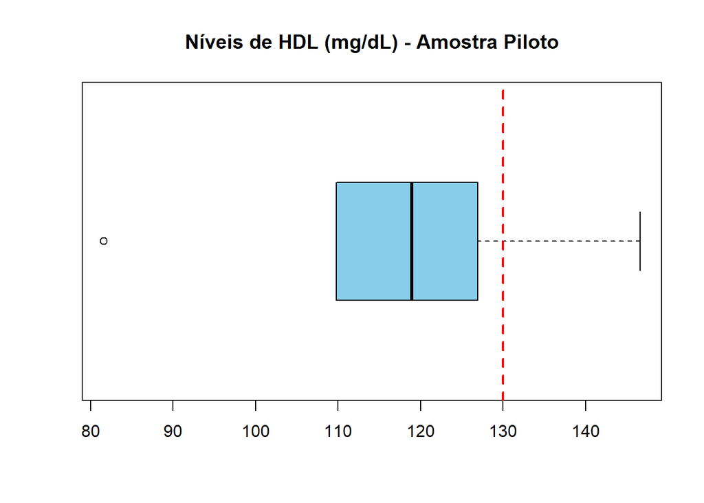

```r
boxplot(piloto, horizontal = TRUE, col = "skyblue",
        main = "Níveis de HDL (mg/dL) - Amostra Piloto")
abline(v = 130, col = "red", lwd = 2, lty = 2)  # valor de referência
```

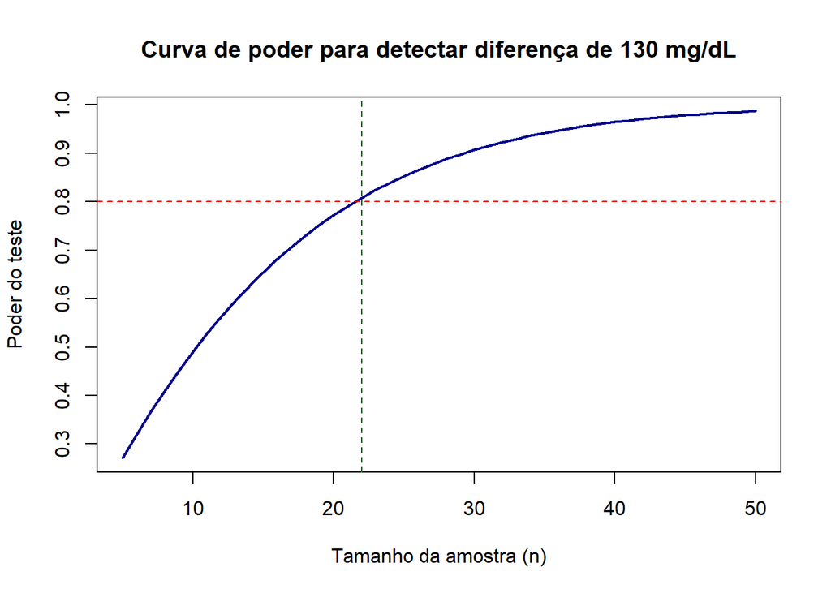

```r
powers <- sapply(5:50, function(n)
  pwr.t.test(n = n, d = efeito, sig.level = 0.05,
             type = "one.sample", alternative = "less")$power)

plot(5:50, powers, type = "l", lwd = 2, col = "darkblue",
     xlab = "Tamanho da amostra (n)", ylab = "Poder do teste",
     main = "Curva de poder para detectar diferença de 130 mg/dL")
abline(h = 0.8, col = "red", lty = 2)
abline(v = ceiling(pwr.t.test(d = efeito, sig.level = 0.05,
                              power = 0.8, type = "one.sample",
                              alternative = "less")$n),
       col = "darkgreen", lty = 2)
```

O boxplot mostra como os dados se distribuem em relação ao valor de referência (130 mg/dL), e a curva de poder do teste mostra que, com aproximadamente 22 indivíduos, atingimos 80% de poder estatístico, confirmando os resultados.

**2)** Considerando a pesquisa do exercício anterior, os níveis de colesterol de pacientes submetidos ao medicamento D foram avaliados e estão descritos abaixo.

| 81.6 146.6 118.9 126.9 109.8 138.2 102.2 120.8 134.0 128.6 117.5 110.5 150.4 114.1 108.3 90.6 123.9 114.3 93.9 \ |
| --- |
| 128.1 121.7 108.0 102.0 113.0 111.2 123.3 129.3 135.6 118.2 136.7 |

**a.** Verifique a suposição de normalidade da variável do estudo (utilize pelo menos dois testes).

**Resposta:**

```r
hdl <- c(
  81.6, 146.6, 118.9, 126.9, 109.8, 138.2, 102.2, 120.8, 134.0, 128.6,
  117.5, 110.5, 150.4, 114.1, 108.3, 90.6, 123.9, 114.3, 93.9, 128.1,
  121.7, 108.0, 102.0, 113.0, 111.2, 123.3, 129.3, 135.6, 118.2, 136.7
)
length(hdl)
```

```
## [1] 30
```

```r
# 1) Kolmogorov–Smirnov "exato" (nota: pressupõe média e dp conhecidos)
ks_exato <- ks.test(hdl, "pnorm", mean(hdl), sd(hdl))

library(nortest)
# 2) Lilliefors (KS adaptado quando média e dp são estimados)
lillie   <- lillie.test(hdl)

# 3) Anderson–Darling
ad       <- ad.test(hdl)

# 4) Cramér–von Mises
cvm      <- cvm.test(hdl)

# 5) Shapiro–Wilk
shapiro  <- shapiro.test(hdl)

ks_exato
```

```
##
##  Exact one-sample Kolmogorov-Smirnov test
##
## data:  hdl
## D = 0.084748, p-value = 0.9698
## alternative hypothesis: two-sided
```

```r
lillie
```

```
##
##  Lilliefors (Kolmogorov-Smirnov) normality test
##
## data:  hdl
## D = 0.084748, p-value = 0.8419
```

```r
ad
```

```
##
##  Anderson-Darling normality test
##
## data:  hdl
## A = 0.13281, p-value = 0.9776
```

```r
cvm
```

```
##
##  Cramer-von Mises normality test
##
## data:  hdl
## W = 0.017394, p-value = 0.9844
```

```r
shapiro
```

```
##
##  Shapiro-Wilk normality test
##
## data:  hdl
## W = 0.98995, p-value = 0.9909
```

```r
pvals <- c(
  `KS (exato)`       = ks_exato$p.value,
  `Lilliefors (KS)`  = lillie$p.value,
  `Anderson–Darling` = ad$p.value,
  `Cramér–von Mises` = cvm$p.value,
  `Shapiro–Wilk`     = shapiro$p.value
)
pvals
```

```
##       KS (exato)  Lilliefors (KS) Anderson–Darling Cramér–von Mises
##        0.9698082        0.8419419        0.9776389        0.9844137
##     Shapiro–Wilk
##        0.9908705
```

Em todos os testes (KS, Lilliefors, Anderson–Darling, Cramér–von Mises e Shapiro–Wilk) os p-valores foram muito superiores a 0,05, indicando ausência de evidências para rejeitar a hipótese nula de normalidade.

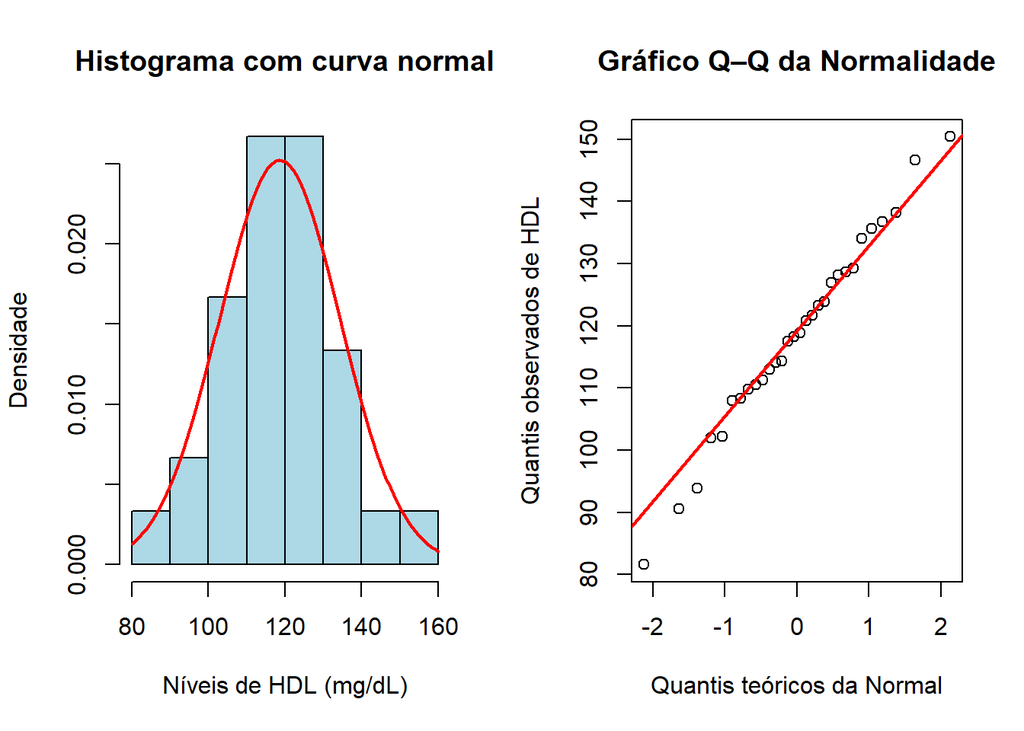

```r
par(mfrow = c(1, 2))

# Histograma com curva normal ajustada
hist(hdl, probability = TRUE, col = "lightblue",
     main = "Histograma com curva normal",
     xlab = "Níveis de HDL (mg/dL)",
     ylab = "Densidade")

curve(dnorm(x, mean(hdl), sd(hdl)), add = TRUE, lwd = 2, col = "red")

# Q–Q plot
qqnorm(hdl, main = "Gráfico Q–Q da Normalidade",
            xlab = "Quantis teóricos da Normal",
            ylab = "Quantis observados de HDL")
qqline(hdl, col = "red", lwd = 2)
```

```r
par(mfrow = c(1, 1))
```

De fato, os gráficos (histograma com curva normal e Q–Q plot) corroboram essa conclusão, sugerindo que a distribuição dos níveis de HDL é aproximadamente normal.

**b.** O nível médio de colesterol HDL destes pacientes é menor do que 130mg/dl? Utilize um nível de significância de 0,05.

**Resposta:** Apresentando as hipóteses, o nível de significância, o valor da estatística do teste, valor de p e a conclusão de cada teste estatístico, temos:

```r
media_hdl  <- mean(hdl)
dp_hdl     <- sd(hdl)

## --- TESTE t ---
t.test(hdl, mu = 130, alternative = "less", conf.level = 0.95)
```

```
##
##  One Sample t-test
##
## data:  hdl
## t = -3.9422, df = 29, p-value = 0.000234
## alternative hypothesis: true mean is less than 130
## 95 percent confidence interval:
##      -Inf 123.5173
## sample estimates:
## mean of x
##  118.6067
```

```r
## --- Wilcoxon (mediana < 130) ---
wilcox.test(hdl, mu = 130, alternative = "less", conf.int = TRUE, conf.level = 0.95)
```

```
##
##  Wilcoxon signed rank exact test
##
## data:  hdl
## V = 70, p-value = 0.0002301
## alternative hypothesis: true location is less than 130
## 95 percent confidence interval:
##    -Inf 123.75
## sample estimates:
## (pseudo)median
##          118.8
```

Como anteriormente, realizamos um **teste t de uma amostra** para verificar se a média de HDL era menor do que 130 mg/dL. As hipóteses consideradas foram:
$$H_0:\; \mu = 130 \quad \text{vs} \quad H_1:\; \mu < 130.$$

Adotando nível de significância de 5%, obteve-se estatística do teste $t = -3.9422$ com $gl = 29$, resultando em valor de $p = 0.000234$. Como $p < 0,05$, rejeita-se $H_0$, indicando que há evidência estatística de que a média de HDL seja inferior a 130 mg/dL.

Do mesmo modo, complementamos com o **teste de Wilcoxon signed-rank** para a mediana. As hipóteses foram:
$$H_0:\; \text{mediana} = 130 \quad \text{vs} \quad H_1:\; \text{mediana}
< 130.$$
O resultado foi $V = 70$ com valor de $p = 0.0002301$. Novamente, como $p < 0,05$, rejeita-se $H_0$. Assim, ambos os testes levam à mesma conclusão: de fato, existe evidência estatística, com nível de 5% de que o tratamento reduza os níveis de HDL para valores médios ou medianos inferiores a 130 mg/dL.

**c.** Obtenha o intervalo de confiança de 95% para o nível de colesterol médio destes pacientes

**Resposta:** Como a variância populacional é desconhecida, o intervalo de confiança de 95% para a média de HDL pode ser obtida pela distribuição t-studet. Segue que

```r
library(ggplot2)
# Estatísticas
n     <- length(hdl)
media <- mean(hdl)
media
```

```
## [1] 118.6067
```

```r
dp    <- sd(hdl)
erro  <- qt(0.975, df = n-1) * dp / sqrt(n)

lim_inf <- media - erro
lim_sup <- media + erro
c(lim_inf, lim_sup)
```

```
## [1] 112.6957 124.5176
```

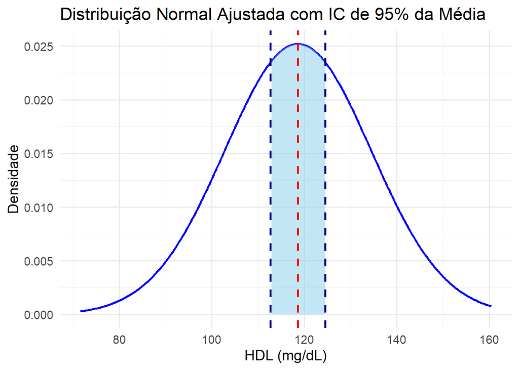

```r
# Curva normal ajustada
x_vals <- seq(min(hdl)-10, max(hdl)+10, length.out = 300)
dens   <- dnorm(x_vals, mean = media, sd = dp)
df_plot <- data.frame(x = x_vals, y = dens)
df_ic   <- subset(df_plot, x >= lim_inf & x <= lim_sup)

# Gráfico
ggplot(df_plot, aes(x, y)) +
  geom_line(color = "blue", size = 1) +
  geom_area(data = df_ic, aes(x, y), fill = "skyblue", alpha = 0.5) +
  geom_vline(xintercept = media, color = "red", linetype = "dashed", size = 1) +
  geom_vline(xintercept = lim_inf, color = "darkblue", linetype = "dashed", size = 1) +
  geom_vline(xintercept = lim_sup, color = "darkblue", linetype = "dashed", size = 1) +
  labs(title = "Distribuição Normal Ajustada com IC de 95% da Média",
       x = "HDL (mg/dL)",
       y = "Densidade") +
  theme_minimal(base_size = 14)
```

Portanto, o intervalo de confiança é [112.6957; 124.5176] e a média estimada está em torno de 118.6 mg/dL e que, com 95% de confiança, o verdadeiro valor da média populacional de HDL está dentro do intervalo.

**3)** A secretaria municipal afirmou que no máximo 10% das residências possuem criadouros de dengue. Um levantamento foi realizado e foram encontrados criadouros de dengue em 42 de 596 residências visitadas.

**a.** Com nível de significância de 0,05, verifique a veracidade da afirmação.

```r
x <- 42; n <- 596; p0 <- 0.10

# Teste aproximado (sem correção), unilateral à ESQUERDA
prop.test(x, n, p = p0, alternative = "less", correct = FALSE)
```

```
##
##  1-sample proportions test without continuity correction
##
## data:  x out of n, null probability p0
## X-squared = 5.7748, df = 1, p-value = 0.008129
## alternative hypothesis: true p is less than 0.1
## 95 percent confidence interval:
##  0.00000000 0.08972496
## sample estimates:
##         p
## 0.0704698
```

```r
# Teste exato binomial, unilateral à ESQUERDA
binom.test(x, n, p = p0, alternative = "less")
```

```
##
##  Exact binomial test
##
## data:  x and n
## number of successes = 42, number of trials = 596, p-value = 0.007565
## alternative hypothesis: true probability of success is less than 0.1
## 95 percent confidence interval:
##  0.00000000 0.09019559
## sample estimates:
## probability of success
##              0.0704698
```

Com base em uma amostra de $n = 596$ residências, das quais $x = 42$ apresentaram criadouros, obteve-se uma proporção amostral de

$$\hat{p} = \frac{42}{596} \approx 0{,}0705 \; (7{,}05\%).$$

Ao realizar o teste unilateral à esquerda de $H_0: p = 0{,}10$ contra $H_1: p < 0{,}10$, tanto o teste aproximado de proporções quanto o teste binomial exato resultaram em *p*-valores inferiores a 0,05 ($\approx$ 0,007–0,008).

Assim, rejeita-se $H_0$ ao nível de significância de 5%. Portanto, conclui-se que a proporção populacional de residências com criadouros de dengue é significativamente inferior a 10%, validando e até fortalecendo a afirmação de que no máximo 10% das residências apresentam o problema.

**b.** Calcule o intervalo de confiança de 95% para a proporção de residência com criadouro de dengue.

**Resposta:** Calculando o intervalo de confiança de 95%, temos:

```r
prop.test(x, n, correct = FALSE)$conf.int
```

```
## [1] 0.05255510 0.09388602
## attr(,"conf.level")
## [1] 0.95
```

```r
binom.test(x, n, alternative = "less")$conf.int
```

```
## [1] 0.00000000 0.09019559
## attr(,"conf.level")
## [1] 0.95
```

Portanto, os intervalos de confiança de 95% obtidos foram, respectivamente, $[0,0526; 0,0939]$ e $[0,0000; 0,0902]$.  
Observa-se que o intervalo unilateral superior de 95% possui limite máximo inferior a 10%, o que reforça a evidência de que a verdadeira proporção de residências com criadouros é menor do que o valor estipulado pela Secretaria Municipal.

**c.** Quantas residências devem ser avaliadas num próximo levantamento, considerando o nível de significância de 0,05 e poder de 80% com objetivo de avaliar a afirmação da secretaria municipal?

**Resposta:**

```r
p1 <- 42/596
ES  <- 2*asin(sqrt(p1)) - 2*asin(sqrt(p0))
pwr.p.test(h = ES, sig.level = 0.05, power = 0.80, alternative = "less")
```

```
##
##      proportion power calculation for binomial distribution (arcsine transformation)
##
##               h = -0.106136
##               n = 548.836
##       sig.level = 0.05
##           power = 0.8
##     alternative = less
```

Para avaliar a afirmação da Secretaria Municipal com poder estatístico adequado, deve-se planejar um próximo levantamento com **aproximadamente 549 residências**. Em termos práticos, recomenda-se arredondar para **cerca de 550 a 600 residências**, garantindo robustez frente a possíveis perdas de dados.